# Overview

## Data Visualization is needed to see the characteristics from the entire dataset

## Headline from this notebook

[output not shown]

# Dataset Description

#### Craigslist is the world's largest collection of used vehicles for sale, yet it's very difficult to collect all of them in the same place. I built a scraper for a school project and expanded upon it later to create this dataset which includes every used vehicle entry within the United States on Craigslist.

1. url = Link to listing
2. city = Craigslist region in which this listing was posted
3. city_url = Link to region page
4. price = Price of vehicle
5. year = Year of vehicle
6. manufacturer = Manufacturer of vehicle
7. make = Make of vehicle
8. condition = Condition of vehicle
9. cylinders = Number of cylinders of vehicle
10. fuelFuel = taken by vehicle
11. odometer = Miles vehicle has been driven
12. title_status = Title status of vehicle (e.g. clean - this vehicle has all legal documents. missing - these documents are missing)
13. transmission = Transmission of vehicle
14. VIN = Vehicle Identification Number
15. drive = Drive of vehicle
16. size = Size of vehicle
17. type = Vehicle type
18. paint_color = Color of vehicle
19. image_url = Link to image of vehicle
20. desc = Listing description provided by owner
21. lat = Latitude of vehicle (not precise but very close)
22. long = Longitude of vehicle (not precise but very close)

# Data Preparation

## Import Module

```python
import numpy as np
import pandas as pd
import seaborn as sns
import matplotlib.pyplot as plt
import numpy as np # linear algebra
import pandas as pd # data processing, CSV file I/O (e.g. pd.read_csv)
import seaborn as sns
import matplotlib.pyplot as plt
%matplotlib inline

import plotly.graph_objs as go
from plotly.offline import download_plotlyjs, init_notebook_mode, plot, iplot
```

## Load Dataset

```python
#data=pd.read_csv('craigslistVehicles.csv')
datafull=pd.read_csv('craigslistVehiclesFull.csv')
print(datafull.shape)
```

```
(1723065, 26)
```

### Lookup the dataset

```python
datafull.head()
```

|  | url | city | price | year | manufacturer | make | condition | cylinders | fuel | odometer | ... | paint_color | image_url | lat | long | county_fips | county_name | state_fips | state_code | state_name | weather |
| --- | --- | --- | --- | --- | --- | --- | --- | --- | --- | --- | --- | --- | --- | --- | --- | --- | --- | --- | --- | --- | --- |
| 0 | https://marshall.craigslist.org/cto/d/2010-dod... | marshall | 11900 | 2010.0 | dodge | challenger se | good | 6 cylinders | gas | 43600.0 | ... | red | https://images.craigslist.org/00i0i_2ggH1eKDNK... | 43.4775 | -96.7041 | 46083.0 | Lincoln | 46.0 | SD | South Dakota | 38.0 |
| 1 | https://marshall.craigslist.org/cto/d/fleetwoo... | marshall | 1515 | 1999.0 | NaN | fleetwood | NaN | NaN | gas | NaN | ... | NaN | https://images.craigslist.org/00M0M_irjh7SjEcU... | 44.7612 | -96.6907 | 46039.0 | Deuel | 46.0 | SD | South Dakota | 38.0 |
| 2 | https://marshall.craigslist.org/cto/d/2008-for... | marshall | 17550 | 2008.0 | ford | f-150 | NaN | NaN | gas | NaN | ... | NaN | https://images.craigslist.org/00s0s_eL2XFhEUcx... | 44.1415 | -103.2052 | 46093.0 | Meade | 46.0 | SD | South Dakota | 38.0 |
| 3 | https://marshall.craigslist.org/cto/d/ford-tau... | marshall | 2800 | 2004.0 | ford | taurus | good | 6 cylinders | gas | 168591.0 | ... | grey | https://images.craigslist.org/00L0L_5HUR1nQjt8... | 43.2845 | -95.5930 | 19143.0 | Osceola | 19.0 | IA | Iowa | 47.0 |
| 4 | https://marshall.craigslist.org/cto/d/2001-gra... | marshall | 400 | 2001.0 | NaN | 2001 Grand Prix | NaN | NaN | gas | 217000.0 | ... | NaN | https://images.craigslist.org/00n0n_bJJ1XnonSG... | 43.0261 | -94.4064 | 19109.0 | Kossuth | 19.0 | IA | Iowa | 47.0 |

5 rows × 26 columns

## Drop Useless Variable

```python
datafull=datafull.drop(['url','image_url'],axis=1)
datafull.head()
```

|  | city | price | year | manufacturer | make | condition | cylinders | fuel | odometer | title_status | ... | type | paint_color | lat | long | county_fips | county_name | state_fips | state_code | state_name | weather |
| --- | --- | --- | --- | --- | --- | --- | --- | --- | --- | --- | --- | --- | --- | --- | --- | --- | --- | --- | --- | --- | --- |
| 0 | marshall | 11900 | 2010.0 | dodge | challenger se | good | 6 cylinders | gas | 43600.0 | clean | ... | coupe | red | 43.4775 | -96.7041 | 46083.0 | Lincoln | 46.0 | SD | South Dakota | 38.0 |
| 1 | marshall | 1515 | 1999.0 | NaN | fleetwood | NaN | NaN | gas | NaN | clean | ... | NaN | NaN | 44.7612 | -96.6907 | 46039.0 | Deuel | 46.0 | SD | South Dakota | 38.0 |
| 2 | marshall | 17550 | 2008.0 | ford | f-150 | NaN | NaN | gas | NaN | clean | ... | NaN | NaN | 44.1415 | -103.2052 | 46093.0 | Meade | 46.0 | SD | South Dakota | 38.0 |
| 3 | marshall | 2800 | 2004.0 | ford | taurus | good | 6 cylinders | gas | 168591.0 | clean | ... | sedan | grey | 43.2845 | -95.5930 | 19143.0 | Osceola | 19.0 | IA | Iowa | 47.0 |
| 4 | marshall | 400 | 2001.0 | NaN | 2001 Grand Prix | NaN | NaN | gas | 217000.0 | clean | ... | NaN | NaN | 43.0261 | -94.4064 | 19109.0 | Kossuth | 19.0 | IA | Iowa | 47.0 |

5 rows × 24 columns

## Handling Missing Value

### Identify Missing Value from each dataset

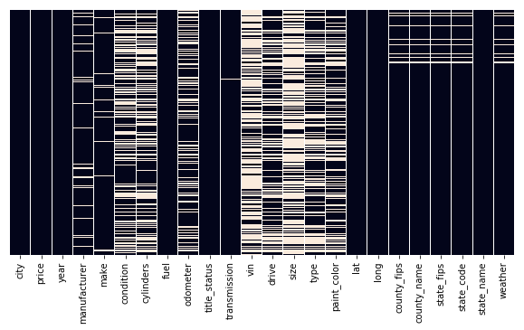

```python
plt.figure(figsize=(10,5))
sns.heatmap(datafull.isnull(), yticklabels=False, cbar=False)
```

White color from the heatmap above sign that there are missing values From the heatmap above, we can see that variable 'vin', 'size','type' and 'condition' have very much missing value

```python
#count how much the percentage of missing value for each field
percentage = round(datafull.isnull().sum()/len(datafull)*100,2).sort_values(ascending = False)
percentage
```

```
size            65.23
vin             64.90
type            40.80
condition       40.67
paint_color     40.37
cylinders       40.12
drive           38.41
odometer        32.74
manufacturer     7.92
make             4.05
weather          3.45
county_fips      3.41
county_name      3.41
state_fips       3.41
state_code       3.41
fuel             0.60
transmission     0.52
year             0.37
title_status     0.15
lat              0.00
state_name       0.00
long             0.00
price            0.00
city             0.00
dtype: float64
```

From the Missing value visualization from 'datafull' dataset, we can see that variable 'size','condition','vin', and 'type' have above 40% missing value from the entire rows in each variable. These variables should be dropped to avoid the bias from the analysis (EDA)

### Drop Missing Values from variable year

We can't impute the missing value from variable 'year' with mean, median, or mode. We should drop it

```python
datafull['year'].value_counts().tail()
```

```
302.0     1
1813.0    1
1904.0    1
1907.0    1
718.0     1
Name: year, dtype: int64
```

```python
print(datafull.shape)
datafull=datafull[datafull['year'].isnull()==False]
print(datafull.shape)
```

```
(1723065, 24)
(1716750, 24)
```

#### Categorical Missing Value Imputation with Mode

```python
datafull['manufacturer'].fillna(datafull['manufacturer'].mode()[0], inplace=True)
datafull['cylinders'].fillna(datafull['cylinders'].mode()[0], inplace=True)
datafull['drive'].fillna(datafull['drive'].mode()[0], inplace=True)
datafull['make'].fillna(datafull['make'].mode()[0], inplace=True)
datafull['state_code'].fillna(datafull['state_code'].mode()[0], inplace=True)
datafull['county_name'].fillna(datafull['county_name'].mode()[0], inplace=True)
datafull['fuel'].fillna(datafull['fuel'].mode()[0], inplace=True)
datafull['transmission'].fillna(datafull['transmission'].mode()[0], inplace=True)
datafull['title_status'].fillna(datafull['title_status'].mode()[0], inplace=True)
datafull['paint_color'].fillna(datafull['paint_color'].mode()[0], inplace=True)
```

#### Numerical Missing Value Imputation with Median

I choose median as the imputer because median is a robust method to avoid the effect of outlier.

```python
datafull.fillna(datafull.median(), inplace=True)
```

#### Drop the Variable

variable 'size','condition','vin', and 'type' have above 40% missing value from the entire rows in each variable. These variables should be dropped to avoid the bias from the analysis (EDA)

```python
datafull=datafull.drop(['size','vin','type','condition'],axis=1)
```

#### Re-Check the percentage of missing value after had been imputed

```python
#count how much the percentage of missing value for each field
percentage = round(datafull.isnull().sum()/len(datafull)*100,2).sort_values(ascending = False)
percentage
```

```
weather         0.0
state_name      0.0
price           0.0
year            0.0
manufacturer    0.0
make            0.0
cylinders       0.0
fuel            0.0
odometer        0.0
title_status    0.0
transmission    0.0
drive           0.0
paint_color     0.0
lat             0.0
long            0.0
county_fips     0.0
county_name     0.0
state_fips      0.0
state_code      0.0
city            0.0
dtype: float64
```

### Split Categorical and Numerical Variable

```python
Categorical=datafull.drop(['price','odometer','county_fips','lat','long','state_fips','weather','year'],axis=1)
Numerical=datafull[['price','odometer','county_fips','lat','long','state_fips','weather']]
print(Categorical.shape, Numerical.shape)
```

```
(1716750, 12) (1716750, 7)
```

### Statistics Summary from the Numerical Variable

```python
Numerical.describe()
```

|  | price | odometer | county_fips | lat | long | state_fips | weather |
| --- | --- | --- | --- | --- | --- | --- | --- |
| count | 1.716750e+06 | 1.716750e+06 | 1.716750e+06 | 1.716750e+06 | 1.716750e+06 | 1.716750e+06 | 1.716750e+06 |
| mean | 1.078220e+05 | 1.115248e+05 | 2.839790e+04 | 3.877014e+01 | -9.369824e+01 | 2.831420e+01 | 5.376770e+01 |
| std | 1.006240e+07 | 1.123442e+05 | 1.575718e+04 | 5.976318e+00 | 1.694882e+01 | 1.573565e+01 | 7.671000e+00 |
| min | 1.000000e+00 | 0.000000e+00 | 1.001000e+03 | -8.481005e+01 | -1.000000e+03 | 1.000000e+00 | 2.900000e+01 |
| 25% | 3.295000e+03 | 8.453700e+04 | 1.305100e+04 | 3.489831e+01 | -1.053231e+02 | 1.300000e+01 | 4.800000e+01 |
| 50% | 7.000000e+03 | 1.070000e+05 | 2.900700e+04 | 3.940500e+01 | -8.823960e+01 | 2.900000e+01 | 5.300000e+01 |
| 75% | 1.499700e+04 | 1.299870e+05 | 4.104300e+04 | 4.253604e+01 | -8.103340e+01 | 4.100000e+01 | 5.900000e+01 |
| max | 2.068627e+09 | 1.000000e+07 | 5.604500e+04 | 9.000000e+01 | 1.397061e+02 | 5.600000e+01 | 7.900000e+01 |

From the summary of price, we can see that above 75% from the data or above 15000, there are so many outliers with very big value. From that case, I decide to take the data with price under 15000.

```python
datafull=datafull[datafull['price']<15000]
```

### Boxplot Comparison of Price before dropped under 15000 and after be dropped under 150000

```
Text(0.5,1,'Price Histogram after be dropped under 15000')
```

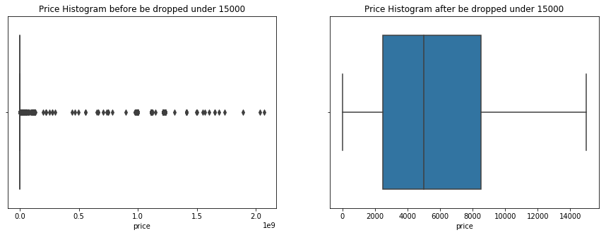

```python
f=plt.figure(figsize=(15,5))
f.add_subplot(1,2,1)
sns.boxplot(Numerical['price'])
plt.title('Price Histogram before be dropped under 15000')
f.add_subplot(1,2,2)
sns.boxplot(datafull['price'])
plt.title('Price Histogram after be dropped under 15000')
```

We can see that the boxplot seems nice after the filtering process

# Data Visualization

## Numerical Variable

### Pearson Correlation Plot

This Method can be used to see the relationship between numerical variables

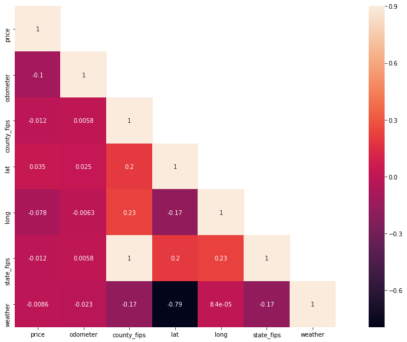

```python
import matplotlib.pyplot as plt
import seaborn as sns
import numpy as np
#create correlation with hitmap

#create correlation
corr = datafull[Numerical.columns].corr(method = 'pearson')

#convert correlation to numpy array
mask = np.array(corr)

#to mask the repetitive value for each pair
mask[np.tril_indices_from(mask)] = False
fig, ax = plt.subplots(figsize = (15,12))
fig.set_size_inches(20,10)
sns.heatmap(corr,
            mask = mask,
            vmax = 0.9,
            square = True,
            annot = True)
```

From the correlation plot we can see that no one variables that has high correlation with price

## Boxplot for Numerical Variables to know the distribution of the variable

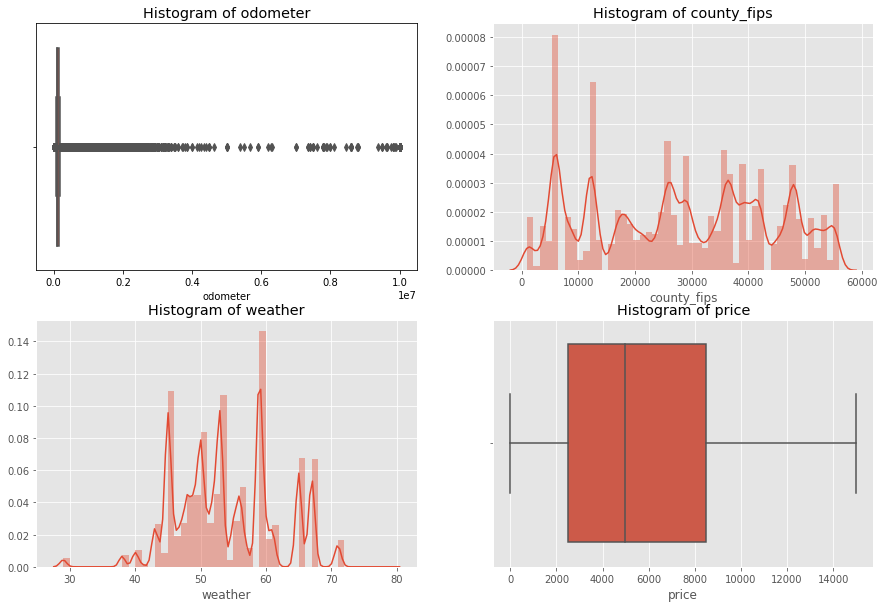

```python
f=plt.figure(figsize=(15,10))

f.add_subplot(2,2,1)
plt.style.use('ggplot')
sns.boxplot(datafull['odometer'])
plt.title('Histogram of odometer')

#plt.show()
f.add_subplot(2,2,2)
sns.distplot(datafull['county_fips'])
plt.title('Histogram of county_fips')

f.add_subplot(2,2,3)
sns.distplot(datafull['weather'])
plt.title('Histogram of weather')

f.add_subplot(2,2,4)
sns.boxplot(datafull['price'])
plt.title('Histogram of price')

plt.show()
```

From the boxplot, we can concluded that odometer has many outlier

## Time Series Plot From The Average of Price each Year and Yearly Count of Cars User

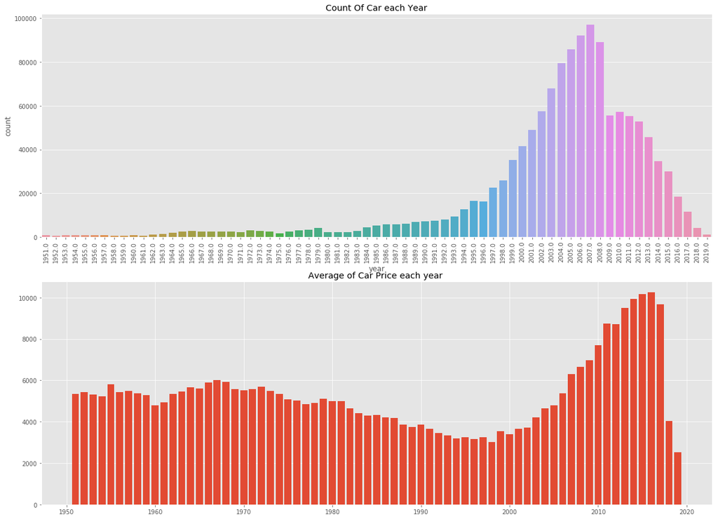

```python
f=plt.figure(figsize=(20,15))

f.add_subplot(2,1,1)
car_year=datafull[datafull['year']>1950]
#car_year['year']=pd.Categorical(car_year['year'])
ax3 = sns.countplot(car_year.year)
plt.xticks(rotation=90)
plt.title("Count Of Car each Year");

f.add_subplot(2,1,2)
data_price=pd.DataFrame(datafull[['year','price']].groupby('year').mean()['price']).reset_index()
data_price_1900=data_price[data_price['year']>1950]
plt.bar(data_price_1900['year'],data_price_1900['price'])
plt.title("Average of Car Price each year ");

plt.show()
```

## Barplot for Categorical Variable

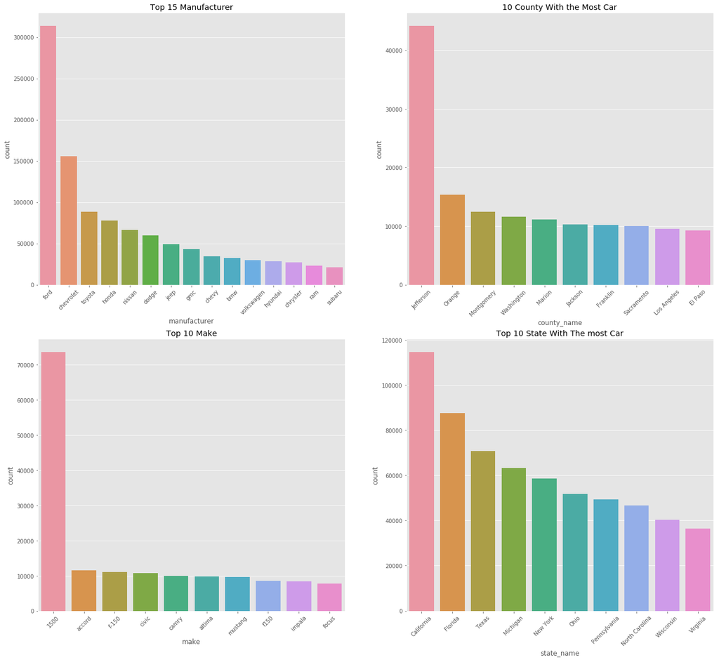

```python
f=plt.figure(figsize=(22,20))

f.add_subplot(2,2,1)
ax = sns.countplot(x='manufacturer',data=datafull,order=datafull['manufacturer'].value_counts().index[:15])
locs, labels = plt.xticks();
plt.setp(labels, rotation=45);
ax.set_title("Top 15 Manufacturer");

#plt.show()
f.add_subplot(2,2,2)
ax = sns.countplot(x='county_name',data=datafull,order=datafull['county_name'].value_counts().index[:10])
locs, labels = plt.xticks();
plt.setp(labels, rotation=45);
ax.set_title("10 County With the Most Car");

f.add_subplot(2,2,3)
ax = sns.countplot(x='make',data=datafull,order=datafull['make'].value_counts().index[:10])
locs, labels = plt.xticks();
plt.setp(labels, rotation=45);
ax.set_title("Top 10 Make");

f.add_subplot(2,2,4)
ax = sns.countplot(x='state_name',data=datafull,order=datafull['state_name'].value_counts().index[:10])
locs, labels = plt.xticks();
plt.setp(labels, rotation=45);
ax.set_title("Top 10 State With The most Car");
plt.show()
```

The picture above is the frequency plot from variable 'manufacturer', 'county name', 'make', and 'state name'

- We can know that the peoples mostly prefer to use Ford cars than others manufactures
- We can also see that peoples mostly prefer to use cars with 1500 as the 'Make' Type
- State with the highest Car Sales is on California
- County with the highest Car Sales is on Jefferson

## Cars Manufacturer

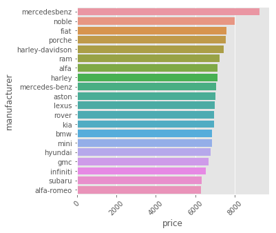

```python
make_price=datafull[['price','manufacturer']].groupby('manufacturer').mean()['price'].sort_values(ascending=False)
#make_price
plt.figure(figsize=(5,5))
sns.barplot(y=make_price.index, x=make_price, order=make_price.index[:20])
plt.xticks(rotation=45)
#plt.show()
```

### Price - Transmission

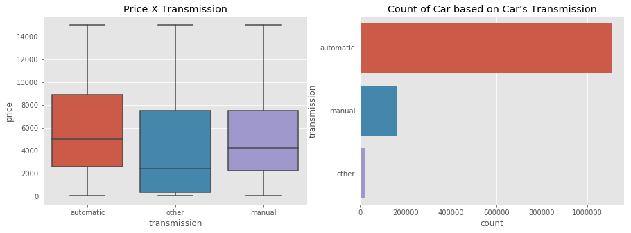

```python
f=plt.figure(figsize=(15,5))
f.add_subplot(1,2,1)
sns.boxplot(y=datafull['price'], x=datafull['transmission'])
plt.title('Price X Transmission')
f.add_subplot(1,2,2)
sns.countplot(y=datafull['transmission'],order = datafull['transmission'].value_counts().index)
plt.title("Count of Car based on Car's Transmission")
plt.show()
```

- Price Comparison between Manual and Automatic Cars is low. Automatic cars are a bit more expensive. Even though the price of the car is too far, most car users prefer automatic cars over manuals. So it can be concluded that car users in USA prefer using automatic cars because more simple

### Price VS Fuel

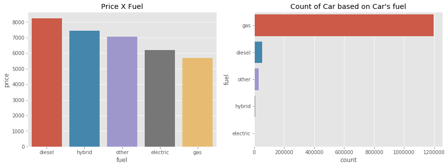

```python
f=plt.figure(figsize=(15,5))
f.add_subplot(1,2,1)
make_price=datafull[['price','fuel']].groupby('fuel').mean()['price'].sort_values(ascending=False)

sns.barplot(x=make_price.index, y=make_price, order=make_price.index[0:20])
plt.xticks(rotation=0)
plt.title('Price X Fuel')

#plt.show()

f.add_subplot(1,2,2)
sns.countplot(y=datafull['fuel'],order = datafull['fuel'].value_counts().index)
plt.title("Count of Car based on Car's fuel")

plt.show()
```

- From the first graph, we can see that cars with Diesel have a higher price than other types of fuel. Gas type cars have the lowest prices. From the second graph, we can see that most cars that will be sold are Gas Fuel type cars, due to the lower price compared to other types of fuel.

### Price VS Title_Status

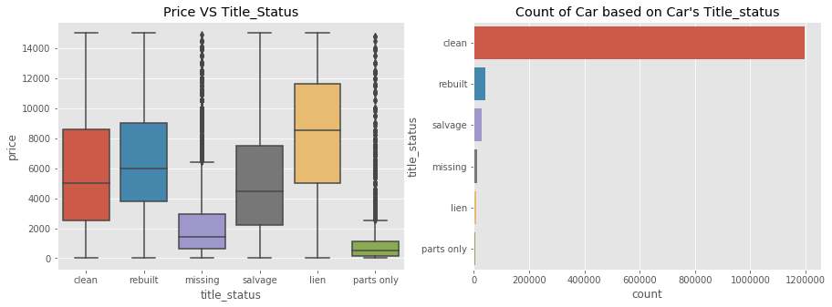

```python
f=plt.figure(figsize=(15,5))

f.add_subplot(1,2,1)

make_price=datafull[['price','title_status']].groupby('title_status').mean()['price'].sort_values(ascending=False)
#sns.barplot(x=make_price.index, y=make_price, order=make_price.index[0:20])
sns.boxplot(y=datafull['price'], x=datafull['title_status'])
plt.xticks(rotation=0)
plt.title('Price VS Title_Status')


f.add_subplot(1,2,2)
sns.countplot(y=datafull['title_status'],order = datafull['title_status'].value_counts().index)
plt.title("Count of Car based on Car's Title_status" )
plt.show()
```

### Price VS Drive

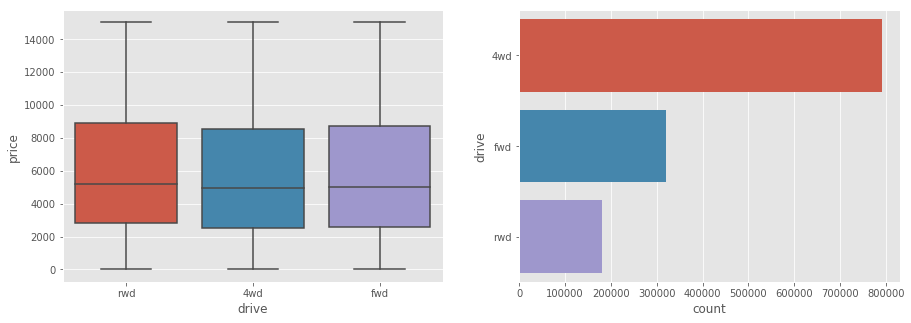

```python
f=plt.figure(figsize=(15,5))

f.add_subplot(1,2,1)
make_price=pd.DataFrame(datafull[['price','drive']].groupby('drive').mean()['price']).reset_index()
sns.boxplot(y=datafull['price'], x=datafull['drive'])
plt.xticks(rotation=0)
#plt.show()


f.add_subplot(1,2,2)
sns.countplot(y=datafull['drive'],order = datafull['drive'].value_counts().index)
plt.show()
```

- From the first graph, it can be seen that there is no significant price difference for each type of drive, but most cars to be sold have 4 tires that can run

## Price VS Paint Color

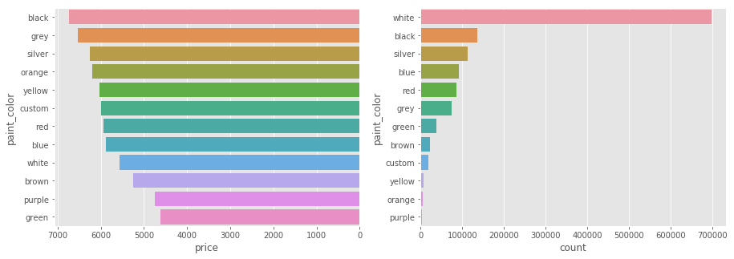

```python
f=plt.figure(figsize=(15,5))

f.add_subplot(1,2,1)
make_price=datafull[['price','paint_color']].groupby('paint_color').mean()['price'].sort_values(ascending=False)
#make_price

sns.barplot(y=make_price.index, x=make_price, order=make_price.index[0:20]).invert_xaxis()
plt.xticks(rotation=0)
#plt.show()

f.add_subplot(1,2,2)
sns.countplot(y=datafull['paint_color'],order = datafull['paint_color'].value_counts().index)
plt.show()
```

- Black cars are usually more expensive than other colors, however, most cars that will be sold are white cars.It can be concluded that car users prefer white cars over other colors

### Cars Listed by State

```python
statecount = datafull.state_code.value_counts()
datamap = dict(type='choropleth',
            colorscale = 'Reds',
            locations = statecount.index,
            z = statecount,
            locationmode = 'USA-states',
            marker = dict(line = dict(color = 'rgb(255,255,255)',width = 2)),
            colorbar = {'title':"Cars listed per State"}
            )
layout = dict(title = 'Cars listed per State',
              geo = dict(scope='usa',
                         showlakes = True,
                         lakecolor = 'rgb(85,173,240)')
             )
choromap = go.Figure(data = [datamap],layout = layout)
iplot(choromap)
```

[interactive chart not shown]

- From the map of the distribution of cars above, it can be seen that the distribution of car sales has not been evenly distributed in the USA. Most cars are sold in California. From there it can be concluded that the demand for car users in USA is more concentrated in the USA.